# Zaawansowane Modele Liniowe Sprawozdanie 2

Błażej Wiórek

3/28/2020

## Zadanie 1

Przyjmując zbiór danych opisujących rejacje pomiędzy prawdopodobieństwami przyjęcia na studia (success) a wynikami testów rachunkowych (numeracy) i poziomu niepewności (anxiety) rozważyć następujące problemy:

1. Wyznacz estymator macierzy kowariancji wektora estymatorów w modelu regresji logistycznej i porównaj wartości na przekątnej z estymatorami odchyleń standardowych zwracanych przez R.
2. Przetestuj jedną hipotezę, że obie zmienne objaśniające nie mają wpływu na zmienną odpowiedzi.
3. Przetestuj hipotezę, że rozkład danych jest zgodny z założonym modelem.
4. Podaj definicję parametru ‘’epsilon’’ i jego wartość domyślną. Wykonaj ponownie obliczenia stosując wartości epsilon ze zbioru: $10^{-1}$, $10^{-2}$, $10^{-3}$ i $10^{-6}$. Porównaj liczbę iteracji i wartości estymatorów poszczególnych parametrów

### Podpunkt a)

Na podstawie twierdzenia podanego na wykładzie, estymator parametrów regresji logistycznej jest asymptotycznie normalny tzn:
$$\hat{\beta} \sim N(\beta, (X^T S(\beta) X)^{-1})$$

Twierdzenie umożliwa obliczenie estymatora macierzy kowariancji wektora estymatorów w modelu regresji logistycznej. Wystarczy wstawić we wzorze na macierz kowariancji $\hat{\beta}$ zamiast $\beta$. Otrzymuje wtedy: $(X^T S(\hat{\beta}) X)^{-1}$.

```
##             R.std..dev. Manual.std..dev.
## (Intercept)      6.7985           6.7992
## numeracy         0.2481           0.2481
## anxiety          0.4804           0.4805
```

Różnica wynika z tego, że wartości obliczone manualnie to wartości asymptotyczne podczas gdy R wykorzystuje tzw. working information matrix otrzymaną w iteracyjnym procesie estymacji parametrów.

### Podpunkt b)

Chce przetestować hipotezę, że obie zmienne objaśniające nie mają wpływu na zmienną objaśnianą. Formalnie test mogę zapisać jako: $H0: \beta_{numeracy} = 0 \land \beta_{anxiety} = 0$ przy alternatywie $HA: \beta_{numeracy} \neq 0 \lor \beta_{anxiety} \neq 0$. Statystyka testowa ma postać: $\chi^2 = D(M1) - D(M2) \sim \chi^2_1$. $D(M1)$ oznacza deviance modelu w którym zachodzi $H0$, natomiast $D(M2)$ oznacza deviance modelu w którym zachodzi $HA$.

```
## [1] "p-value for predictors importance:  2.89591496621638e-10"
```

Tak niska p-wartość daje podstawy do odrzucenia hipotezy zerowej na rzecz hipotezy alternatywnej.

### Podpunkt c)

Nadmierna dyspersja to sytuacja w której wariancja założonego rozkładu jest mniejsza niż wariancja obserwowana w danych. W przypadku regresji logistycznej mogę mówić o nadmiernej dyspersji gdy obserwowana wariancja $y_i$ jest większa niż $Var[\hat{p}] = \frac{p(1-p)}{n}$. Istnieją dwie podstawowe przyczyny występowania tego zjawiska:

1. Prawdopodobieństwo, że Y=1 zmienia się w kolejnych próbach
2. Prawdopodobieństwa w poszczególnych próbach nie spełniają warunku niezależności.

Test na podstawie którego można wnioskować o nadmiernej dyspersji to test dopasowania modelu obliczany na podstawie statystyki Pearsona, residual deviance i liczby stopni swobody residual deviance.

```
## [1] "P-value connected with test for overdispersion:  0.986037709270402"
```

Wysoka p-wartość wskazuje, że brak podstaw do stwierdzenia występowania zjawiska najdmiernej dyspersji.

### Podpunkt d)

Ze względu na to, że analityczne rozwiązanie równania $\nabla l(b) = 0$ (gdzie l(b) to funkcja likelihood względem parametrów modelu) nie istnieje, do obliczenia estymatorów współczynników modelu wykorzystywane są metody numeryczne. Parametr $\epsilon$ umożliwia kontrolę nad liczbą iteracji algorytmu. Zdefiniowany jest on jako $\frac{dev_{old} - dev}{|dev| + 0.1}$. Wartości występujące we wzorze to dewiancja aktualnego modelu oraz dewiancja modelu z poprzedniego kroku. Warto tutaj przypomnieć, że funkcja $l(b)$ jest funkcją wklęsłą co gwarantuje zbieżność algorytmu oraz $dev_{old} - dev \geq 0$. Wniosek jest taki, że zmniejszanie wartości $\epsilon$ spowoduje zwiększenie liczby iteracji ze względu na wymuszenie coraz dokładniejszej aproksymacji minimum globalnego.

```
##   Iteration Epsilon Deviance
## 1         3   0.100  28.3678
## 2         4   0.010  28.2864
## 3         5   0.001  28.2856
## 4         6   0.000  28.2856
```

Zgodnie z oczekiwaniami zmniejszanie $\epsilon$ zwiększało liczbę iteracji oraz zmniejszało wartość statystyki deviance. Warto zauważyć, że różnice pomiędzy $\epsilon = 10^{-3}$ a $\epsilon = 10^{-6}$ są pomijalne. W praktyce dla dużych zbiorów danych zbyt duża liczba kroków algorytmu może w znaczący sposób wydłużyć czas uczenia.

## Zadanie 2

Wygeneruj macierz X wymiaru $n=400$, $p=3$, której elementy są zmiennymi losowymi z rozkładu $N(0, \frac{1}{n})$. Załóżmy, że binarny wektor odpowiedzi jest wygenerowany zgodnie z modelem regresji logistycznej z wektorem beta=(3,3,3). Wyznacz macierz informacji Fishera w punkcie beta i asymptotyczna macierz kowariancji estymatorów największej wiarogodności. Nastepnie 500 razy wygeneruj wektor odpowiedzi zgodnie z powyższym modelem.

Adnotacja: W związku z tym, że dane generowane są zgodnie z określonym schematem należy usunąć intercept z modelu.

### Podpunkt a)

Narysuj histogramy estymatorów beta1, beta2 i beta3 i ‘residual deviance’ i porównaj z ich rozkładami asymptotycznymi.

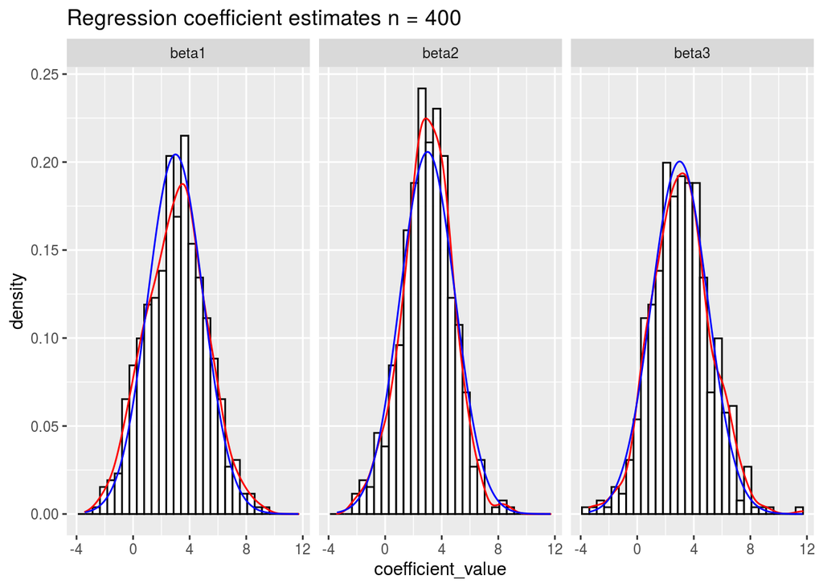

Deviance ma asymptotyczny rozkład postaci: $ResidualDeviance \sim \chi^2_{n-p}$. Na wykresie można zaobserować, że wygenerowane wartości residual deviance znacznie różnią się od rozkładu asymptotycznego z czego mogę wnioskować o tym, że model nie był w stanie dopasować się do danych. Wynika to z tego, że nie zachodzą warunki uzasadniające twierdzenie asymptotyczne, bo $df = n-2 \approx n$ podczas gdy twierdzenie wymaga aby $n >> df$.

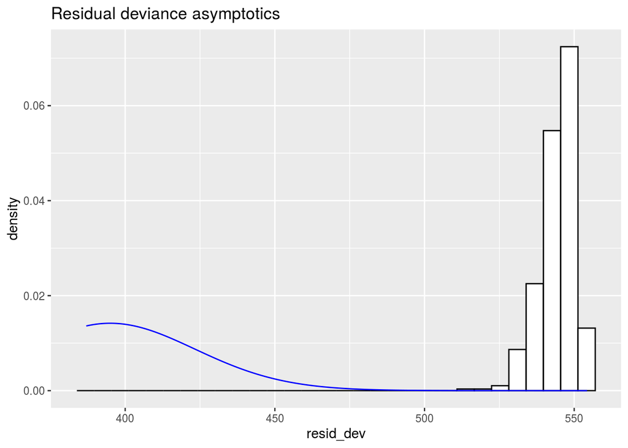

Warto zastanowić się nieco bardziej nad tym problemem. Z histogramów wynika, że model jest w stanie określić poprawne wartości współczynników regresji, jednak współczynniki te mają relatywnie małą istotność. Poniżej zamieszczone zostało podsumowanie dla modelu dopasowanego w taki sposób w jaki dopasowywane są modele w pętli wykonywanej 500 razy. Można zaobserwować, że istotność poszczególnych predyktorów jest niska oraz istnieje niewielka różnica pomiędzy null deviance i residual deviance.

```
##
## Call:
## glm(formula = Y ~ X - 1, family = binomial)
##
## Deviance Residuals:
##    Min      1Q  Median      3Q     Max
## -1.566  -1.108   0.901   1.174   1.624
##
## Coefficients:
##    Estimate Std. Error z value Pr(>|z|)
## X1    4.950      2.065   2.398   0.0165 *
## X2    4.936      2.106   2.344   0.0191 *
## X3    4.310      2.069   2.083   0.0373 *
## ---
## Signif. codes:  0 '***' 0.001 '**' 0.01 '*' 0.05 '.' 0.1 ' ' 1
##
## (Dispersion parameter for binomial family taken to be 1)
##
##     Null deviance: 554.52  on 400  degrees of freedom
## Residual deviance: 538.53  on 397  degrees of freedom
## AIC: 544.53
##
## Number of Fisher Scoring iterations: 4
```

### Podpunkt b)

2. Wyestymuj obciążenie estymatorów beta1, beta2 i beta3.

Obiążenie estymatorów obliczone zostało jako średnia różnica pomiędzy $\beta = 3$ a estymatorem $\hat{\beta}$. Jako, że $\hat{\beta}$ jest estymatorem nieobciążonym oczekuje się, że wartość ta będzie malała wraz ze wzrostem liczby obserwacji (n).

```
##   beta1   beta2   beta3
##  0.0258 -0.0175  0.1197
```

### Podpunkt c)

3. Wyestymuj macierz kowariancji wektora estymatorów (beta1, beta2, beta3) i porównaj z asymptotyczną macierzą kowariancji.

Wyestymowana macierz kowariancji:

```
##         beta1   beta2  beta3
## beta1  4.5196 -0.1448 0.1679
## beta2 -0.1448  3.1981 0.0322
## beta3  0.1679  0.0322 4.3222
```

Prawdziwa macierz kowariancji:

```
##         beta1   beta2  beta3
## beta1  3.8097 -0.0068 0.0576
## beta2 -0.0068  3.7570 0.1972
## beta3  0.0576  0.1972 3.9639
```

## Zadanie 3

Zadanie polega na powtórzenie kroków z zadania 2 dla $n=100$.

### Podpunkt a)

Zmniejszenie liczby obserwacji na podstawie których wyestymowane są współczynniki regresji logistycznej powoduje zwiększenie błędu estymacji współczynników $\beta$. Sytuacja ta jest w pewnym stopniu obserwowalna na poniższym zestawieniu histogamów, jednak zostanie uwypuklona w kolejnych podpunktach.

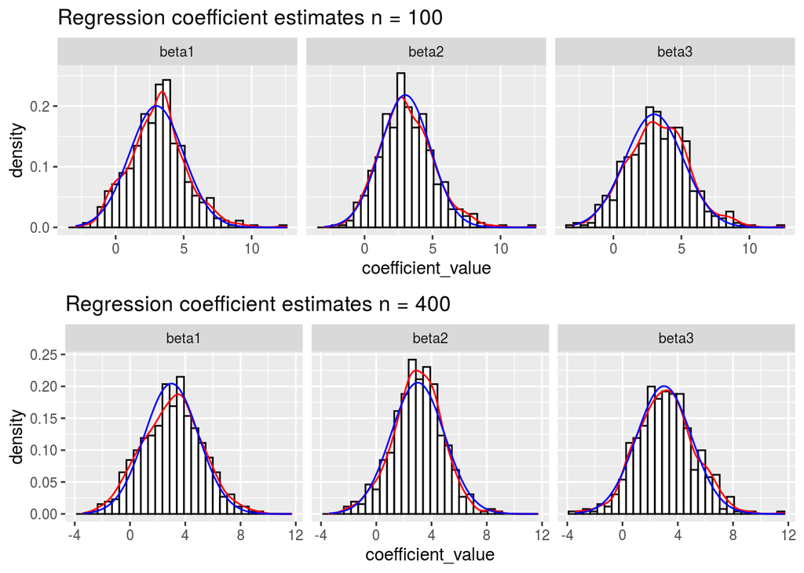

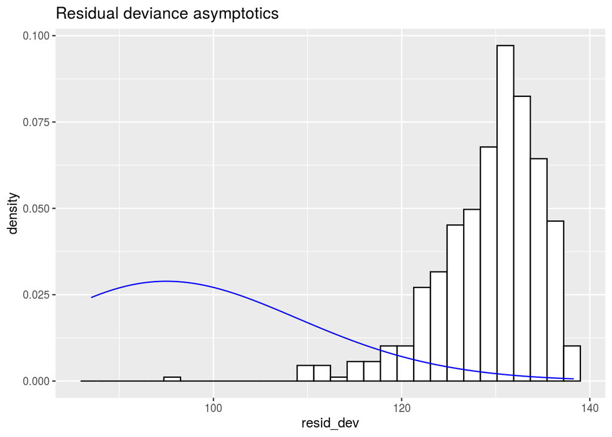

### Podpunkt b)

Warto zauważyć, że bias obliczony na podstawie zbioru treningowego rozmiaru n=100 jest większy niż bias dla zbioru treningowego rozmiaru n=400.

```
##        beta1   beta2  beta3
## n=400 0.0258 -0.0175 0.1197
## n=100 0.0897  0.1215 0.2571
```

### Podpunkt c)

Wyestymowana macierz kowariancji:

```
##        beta1  beta2  beta3
## beta1 4.2791 0.4396 0.3828
## beta2 0.4396 3.9021 0.4419
## beta3 0.3828 0.4419 5.0215
```

Prawdziwa macierz kowariancji:

```
##        beta1  beta2  beta3
## beta1 3.9709 0.5600 0.4082
## beta2 0.5600 3.3413 0.2027
## beta3 0.4082 0.2027 4.5714
```

## Zadanie 4

W przeciwieństwie do poprzedniego zadania, zbiór treningowy został wygenerowany w taki sposób, że istnieje korelacja pomiędzy poszczególnymi predyktorami. Zjawisko to znane jest jako multicollinearity i stanowi efekt niepożądany. Korelacja pomiędzy predyktorami często powoduje problemy ze znalezieniem właściwych parametrów regresji. W szczególności można spodziewać się większej wariancji estymatorów. Przedstawione wyniki zostały wygenerowane na podstawie powtarzania czynności z zadań 2 i 3 dla różnych scenariuszy symulacji.

### Wyniki dla n=400

#### Podpunkt a1)

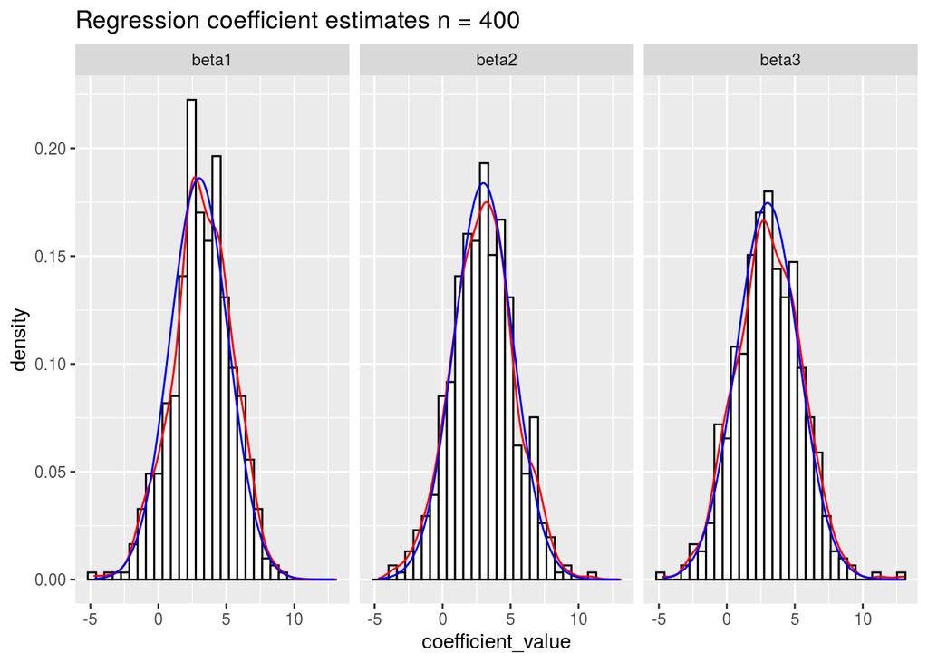

[figure not shown]

#### Podpunkt b1)

```
##   beta1   beta2   beta3
##  0.1993 -0.0241  0.0716
```

#### Podpunkt c1)

```
##         beta1   beta2   beta3
## beta1  4.7749 -1.0621 -1.3857
## beta2 -1.0621  5.1865 -1.4543
## beta3 -1.3857 -1.4543  5.7244
```

```
##         beta1   beta2   beta3
## beta1  4.5909 -0.8195 -1.0349
## beta2 -0.8195  4.7067 -1.3431
## beta3 -1.0349 -1.3431  5.2148
```

### Wyniki dla n=100

#### Podpunkt a2)

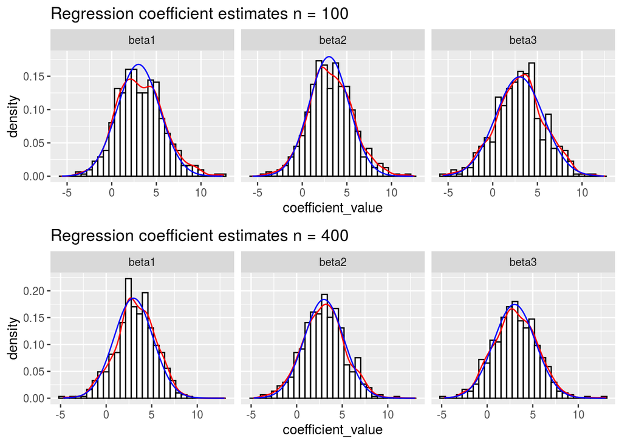

#### Podpunkt b2)

```
##        beta1   beta2  beta3
## n=400 0.1993 -0.0241 0.0716
## n=100 0.1632  0.1645 0.0566
```

[output not shown]

#### Podpunkt c2)

```
##         beta1   beta2   beta3
## beta1  5.6494 -1.0181 -1.5260
## beta2 -1.0181  4.9439 -1.9428
## beta3 -1.5260 -1.9428  7.1552
```

## Podsumownie dla p=3

```
##             beta1   beta2  beta3
## n=400      0.0258 -0.0175 0.1197
## n=100      0.0897  0.1215 0.2571
## n=400 corr 0.1993 -0.0241 0.0716
## n=100 corr 0.1632  0.1645 0.0566
```

Zaproponowane porównanie wyestymowanej wariancji polega na odjęciu wariancji wyestymowanej oraz prawdziwej i wzięciu modułu z tak otrzymanej wartości. W wyniku tej procedury otrzymam 3 wartości mówiące o biasie estymatora wariancji. Otrzymane wartości nie wskazują na żadną oczywistą zależność pomiędzy estymatorami. Jedyną wartością, która odstaje od reszty to bias związany ze zbiorem treningowym rozmiaru n=100 i skorelowanymi predyktorami. W tym przypadku ogólny błąd był największy.

```
##      n.400      n.100 n.400.corr n.100.corr
##     1.6271     1.3192     1.1733     2.1823
```

## Zadanie 5

Aby uniknać przedstawiania wyników dla wszystkich 20 estymatorów, ogranicze się do $\beta_1$, $\beta_2$ oraz $\beta_3$ (tam gdzie jest to konieczne).

### Wyniki dla n=400

#### Podpunkt a)

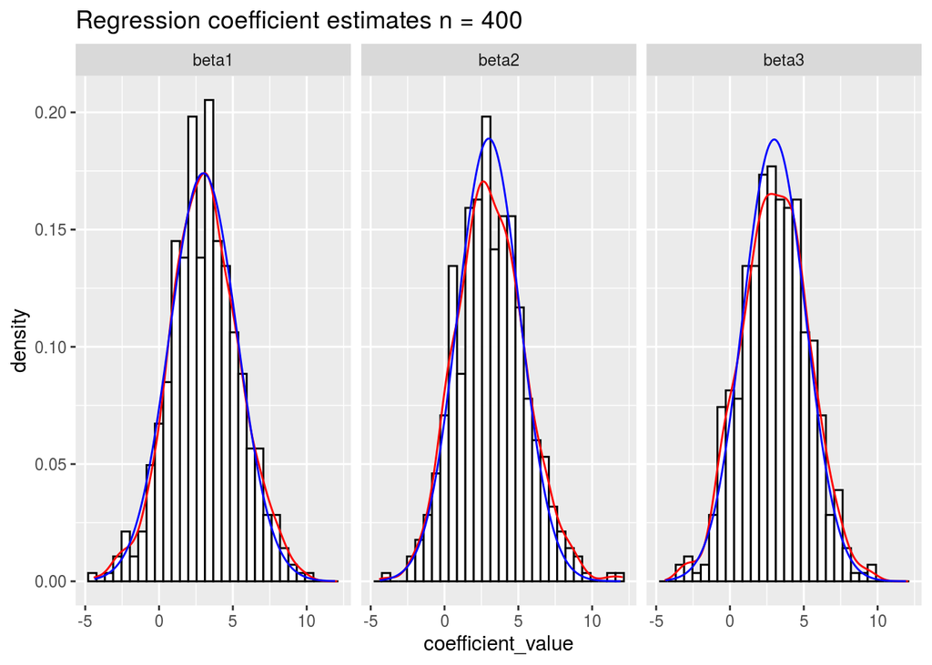

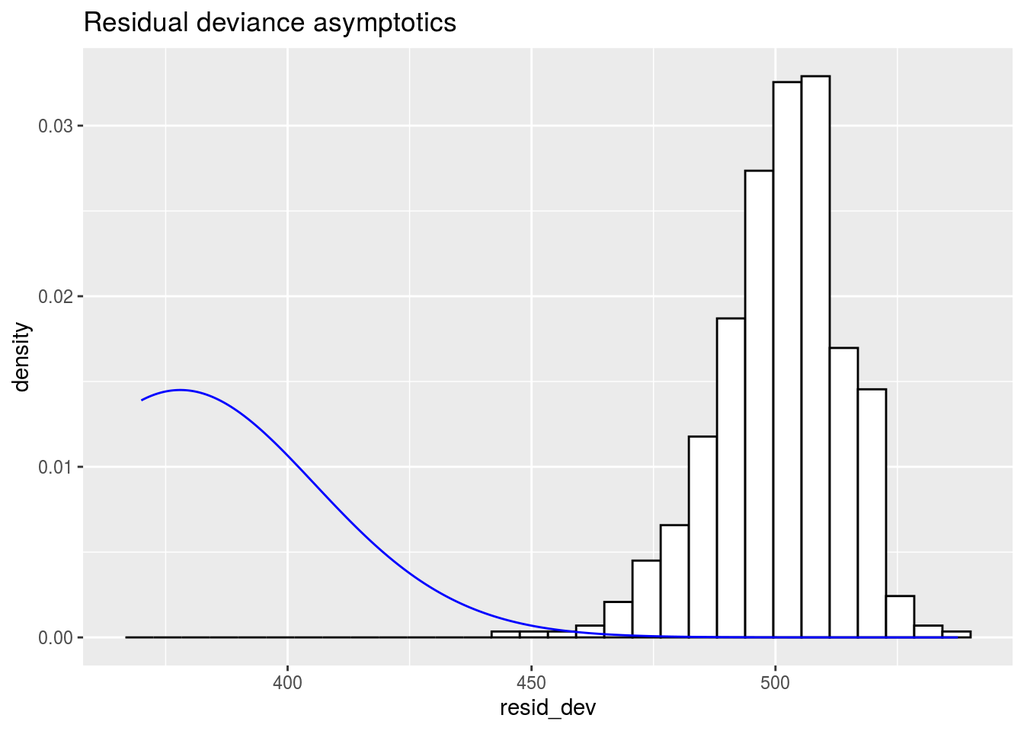

```
##
## Call:
## glm(formula = Y ~ X - 1, family = binomial)
##
## Deviance Residuals:
##     Min       1Q   Median       3Q      Max
## -1.9995  -1.0624  -0.6369   1.0351   2.1066
##
## Coefficients:
##     Estimate Std. Error z value Pr(>|z|)
## X1    1.9714     2.1873   0.901  0.36741
## X2    4.4035     2.1363   2.061  0.03927 *
## X3    1.3245     2.0520   0.645  0.51863
## X4    2.9319     2.2832   1.284  0.19910
## X5   -1.8145     2.2063  -0.822  0.41083
## X6    2.9813     2.1228   1.404  0.16019
## X7    0.2627     2.1960   0.120  0.90478
## X8    3.5878     2.2744   1.577  0.11468
## X9    5.9027     2.2127   2.668  0.00764 **
## X10   4.0251     2.1726   1.853  0.06393 .
## X11   6.5417     2.2455   2.913  0.00358 **
## X12   1.8631     2.2983   0.811  0.41758
## X13   6.6001     2.2793   2.896  0.00378 **
## X14   4.5202     2.1917   2.062  0.03916 *
## X15   3.2858     2.2357   1.470  0.14165
## X16   3.1703     2.1129   1.500  0.13350
## X17   2.7490     2.3311   1.179  0.23830
## X18   1.3486     2.2616   0.596  0.55097
## X19   3.8343     2.2406   1.711  0.08703 .
## X20   2.3033     2.1756   1.059  0.28973
## ---
## Signif. codes:  0 '***' 0.001 '**' 0.01 '*' 0.05 '.' 0.1 ' ' 1
##
## (Dispersion parameter for binomial family taken to be 1)
##
##     Null deviance: 554.52  on 400  degrees of freedom
## Residual deviance: 501.70  on 380  degrees of freedom
## AIC: 541.7
##
## Number of Fisher Scoring iterations: 4
```

#### Podpunkt b)

2. Obciążenie estymatorów

```
##  beta1  beta2  beta3
## 0.0952 0.1316 0.0386
```

#### Podpunkt c)

3. Wyestymuj macierz kowariancji wektora estymatorów (beta1, beta2, beta3) i porównaj z asymptotyczną macierzą kowariancji.

Wyestymowana macierz kowariancji:

```
##        beta1   beta2   beta3
## beta1 5.4049  0.1629  0.3562
## beta2 0.1629  5.3656 -0.0930
## beta3 0.3562 -0.0930  5.0132
```

Prawdziwa macierz kowariancji:

```
##         beta1   beta2   beta3
## beta1  5.2535 -0.0879  0.0108
## beta2 -0.0879  4.4633 -0.1522
## beta3  0.0108 -0.1522  4.4815
```

Wartości wariancji estymatorów (wartości na diagonali) są zbliżone, chociaż wyestymowana wariancja $\hat{\beta_i}$ jest systematycznie większa niż wariancja asymptotyczna.

### Wyniki dla n=100

#### Podpunkt a)

Dla n=100 widać znaczną różnice pomiędzy wartościami wyestymowanymi a asymptotycznym rozkładem.

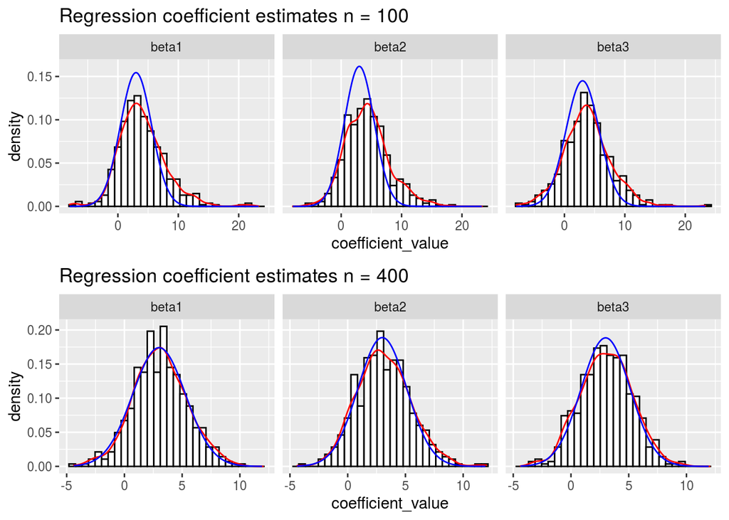

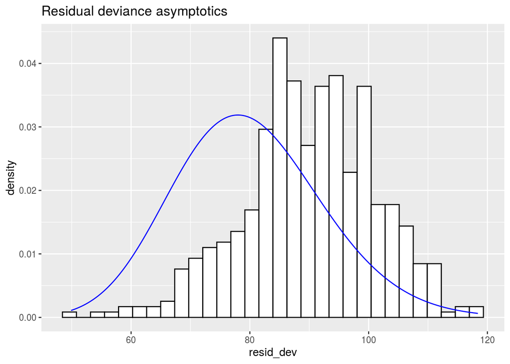

#### Podpunkt b)

```
##        beta1  beta2  beta3
## n=400 0.0952 0.1316 0.0386
## n=100 1.0350 1.3361 0.7660
```

#### Podpunkt c)

Wyestymowana macierz kowariancji:

```
##         beta1   beta2   beta3
## beta1 14.7084  3.1292 -0.1311
## beta2  3.1292 12.9689 -0.9796
## beta3 -0.1311 -0.9796 15.2220
```

Prawdziwa macierz kowariancji:

```
##        beta1   beta2   beta3
## beta1 6.6722  0.4665  0.0687
## beta2 0.4665  6.0891 -0.6044
## beta3 0.0687 -0.6044  7.5691
```

## Przypadek ze skorelowanymi predyktorami

### Wyniki dla n=400

#### Podpunkt a)

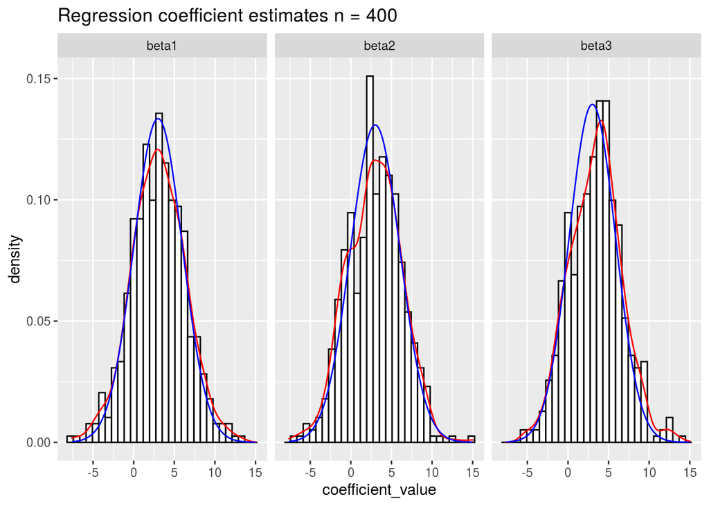

[figure not shown]

#### Podpunkt b)

```
##   beta1   beta2   beta3
##  0.0394 -0.0932  0.3818
```

#### Podpunkt c1)

```
## [1] 10.8412  0.8305  0.3282
```

```
##         beta1   beta2   beta3
## beta1  8.9320  0.3053 -0.5977
## beta2  0.3053  9.2931 -0.3626
## beta3 -0.5977 -0.3626  8.1948
```

### Wyniki dla n=100

#### Podpunkt b)

```
##              beta1         beta2        beta3
## n=400 3.940000e-02 -9.320000e-02 3.818000e-01
## n=100 3.481128e+13  8.921537e+12 3.431245e+13
```

```
## [1] 1.804159e+29 6.406286e+27 1.645022e+29
```

#### Podpunkt c2)

```
## [1] 10.7775 -1.0974  0.9327
```

## Podsumownie dla p=20

Podobnie do przypadku gdzie p=3, wydaje się, że w przypadku eksperymentu zawierającego dane skorelowane, otrzymany bias jest większy. W obu przypadkach wydaje się, że największy wpływ na popełniany błąd ma rozmiar zbioru treningowego.

```
##        n=400  n=100 n=400 corr   n=100 corr
## beta1 0.0952 1.0350     0.0394 3.481128e+13
## beta2 0.1316 1.3361    -0.0932 8.921537e+12
## beta3 0.0386 0.7660     0.3818 3.431245e+13
```

Analogicznie do biasu estymatorów, estymator wariancji poszczególnych współczynników jest większy dla danych skorelowanych. W tym przypadku wydaje się jednak, że kluczową rolę odgrywa romiar zbioru treningowego, a nie korelacja predyktorów.

[output not shown]